# L’API opendatasoft

Author

Claude Grasland

L’objectif de ce chapitre est d’examiner en détail le fonctionnement du site **public.opendatasoft** qui permet d’accèder à des centaines d’API à l’aide de requêtes normalisées. Sans apprendre en détail le fonctionnement de cette API, on va montrer comment créer de petites fonctions facilitant le travail d’exportation des variables ou des données.

On charge les packages utiles :

```r
library(knitr)
library(httr)
library(jsonlite)
library(dplyr)
```

## Liste des API

La première étape consiste à choisir l’API qui nous intéresse parmi plus de 600.

### En parcourant le site

On peut se rendre sur le site pour parcourir les API proposées en allant à l’adresse : https://public.opendatasoft.com

[figure not shown]

### En récupérant le catalogue

Mais il est également possible de téécharger le catalogue général … en se servant d’une API

```r
x<-GET('https://public.opendatasoft.com/api/datasets/1.0/search/?q=&rows=1000&start=0')
y<-fromJSON(rawToChar((x$content)))
cat<-y$datasets$metas
row.names(cat)<-y$datasets$datasetid
kable(head(cat[,c(12,1,6,7,8)]),row.names = F)
```

| license_url | domain | modified | license | publisher |
| --- | --- | --- | --- | --- |
| https://creativecommons.org/licenses/by/4.0/ | public | 2022-12-14T10:45:09+00:00 | CC BY 4.0 | Opendatasoft |
| https://www.etalab.gouv.fr/wp-content/uploads/2018/11/open-licence.pdf | public | 2023-05-17T14:00:17+00:00 | Open License v2.0 | Blablacar |
| NA | public | 2022-04-28T00:02:08+00:00 | NA | Opendatasoft |
| https://www.usa.gov/government-works | public | 2019-10-22T09:33:24+00:00 | U.S. Government Work | U.S. Consumer Product Safety Commission |
| https://www.etalab.gouv.fr/wp-content/uploads/2014/05/Licence_Ouverte.pdf | public | 2015-12-09T11:06:48+00:00 | Open License v1.0 | Ministère de l’Intérieur |
| https://www.etalab.gouv.fr/wp-content/uploads/2014/05/Licence_Ouverte.pdf | public | 2015-12-11T14:08:02+00:00 | Licence Ouverte v1.0 | CAF |

On suppose que le choix s’est porté sur l’API *arbresremarquablesparis2011*

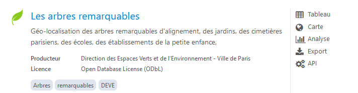

## Liste des variables d’une API

Avant de télécharger les données, on effectue une requête pour connaître les variables du tableau que l’on va télécharger ainsi que les variables pouvant servir de “facettes” c’est-à-dire permettant d’effectuer des requêtes.

### Programme

```r
tab<-"arbresremarquablesparis2011"
url<-paste("https://public.opendatasoft.com/api/v2/catalog/datasets/",tab,"?",sep="")
x<-GET(url)
y<-fromJSON(rawToChar(x$content))
var<-y$dataset$fields

head(var)
```

```
                      name              label         type facet description
1                 geom_x_y          Geo point geo_point_2d    NA          NA
2            arbres_idbase             idbase       double    NA          NA
3       arbres_domanialite        domanialite         text    NA          NA
4    arbres_arrondissement     arrondissement         text    NA          NA
5 arbres_complementadresse complement adresse         text    NA          NA
6            arbres_numero             numero         text    NA          NA
```

```r
var <- var  %>% select(-annotations)
kable(var)
```

| name | label | type | description |
| --- | --- | --- | --- |
| geom_x_y | Geo point | geo_point_2d | NA |
| arbres_idbase | idbase | double | NA |
| arbres_domanialite | domanialite | text | NA |
| arbres_arrondissement | arrondissement | text | NA |
| arbres_complementadresse | complement adresse | text | NA |
| arbres_numero | numero | text | NA |
| arbres_adresse | adresse | text | NA |
| arbres_circonferenceencm | circonference en cm | double | NA |
| arbres_hauteurenm | hauteur en m | double | NA |
| arbres_stadedeveloppement | stade développement | text | NA |
| arbres_pepiniere | pépinière | text | NA |
| arbres_genre | genre | text | NA |
| arbres_espece | espèce | text | NA |
| arbres_varieteoucultivar | varieteoucultivar | text | NA |
| arbres_dateplantation | date de plantation | datetime | NA |
| arbres_libellefrancais | libellé Français | text | NA |
| com_idbase | ID Base | double | NA |
| com_idarbre | ID arbre | double | NA |
| com_site | Site | text | NA |
| com_adresse | Adresse | text | NA |
| com_complement_adresse | Complément d’adresse | text | NA |
| com_arrondissement | Arrondissement | text | NA |
| com_domanialite | Domanialité | text | NA |
| com_nom_usuel | Dénomination usuelle | text | NA |
| com_nom_latin | Dénomination botanique | text | NA |
| com_autorite_taxo | Autorité taxonomique | text | NA |
| com_annee_plantation | Année de plantation | text | NA |
| com_qualification_rem | Qualification remarquable | text | NA |
| com_resume | Résumé | text | NA |
| com_descriptif | Descriptif | text | NA |
| com_delib_num | Numéro de délibération | text | NA |
| com_delib_date | Date de la délibération | text | NA |
| com_label_arbres | Label national | text | NA |
| com_url_pdf | Panonceau | text | NA |
| com_url_photo1 | Photo 1 | text | NA |
| com_copyright1 | Copyright 1 | text | NA |

### Fonction

On le transforme en fonction pour un usage plus simple :

```r
get_variables<-function(idtab = "arbresremarquablesparis2011") {
  url<-paste("https://public.opendatasoft.com/api/v2/catalog/datasets/",idtab,"?",sep="")
  x<-GET(url)
  y<-fromJSON(rawToChar((x$content)))
  var<-y$dataset$fields
  var <- var %>% select(-annotations)
  return(var)
}
```

On peut désormais appliquer notre fonction sur n’importe quel autre tableau du catalogue. Par exemple, si on choisit le tableau `qualite_de-lair-france` on obtient la liste de variables suivante :

```r
var<-get_variables("qualite-de-lair-france")
kable(var)
```

| name | label | type | description |
| --- | --- | --- | --- |
| country | Country Code | text | NA |
| city | City | text | NA |
| location | Location | text | NA |
| coordinates | Coordinates | geo_point_2d | NA |
| measurements_parameter | Pollutant | text | NA |
| measurements_sourcename | Source Name | text | NA |
| measurements_unit | Unit | text | NA |
| measurements_value | Value | double | NA |
| measurements_lastupdated | Last Updated | datetime | NA |
| country_name_en | Country Label | text | NA |

## Récupération des données

### Programme

Par défaut, une API renvoie 10 enregistrements, ce qui permet de se faire une première idée de la structure des données

```r
 x<-GET("https://public.opendatasoft.com/api/records/1.0/search/?dataset=arbresremarquablesparis2011&q=&rows=10")
y<-fromJSON(rawToChar((x$content)))
  don<-y$records$fields
kable(don)
```

| com_url_photo1 | com_idarbre | com_copyright1 | com_descriptif | arbres_complementadresse | com_url_pdf | com_nom_usuel | com_autorite_taxo | com_label_arbres | arbres_pepiniere | arbres_espece | com_domanialite | arbres_circonferenceencm | arbres_arrondissement | com_idbase | arbres_stadedeveloppement | arbres_domanialite | com_arrondissement | com_annee_plantation | com_adresse | arbres_genre | com_complement_adresse | com_site | com_nom_latin | arbres_libellefrancais | com_resume | arbres_adresse | com_qualification_rem | geom_x_y | arbres_idbase | … |
| --- | --- | --- | --- | --- | --- | --- | --- | --- | --- | --- | --- | --- | --- | --- | --- | --- | --- | --- | --- | --- | --- | --- | --- | --- | --- | --- | --- | --- | --- | --- |
| https://capgeo.sig.paris.fr/PdfEtImages/ArbresRemarquables/Photos2023/1/2002352.jpg | 2002433 | Clément Dorval / Ville de Paris | L’if est une essence appartenant à la famille des Taxacées. Conifère à croissance extrêmement lente, sa longévité est exceptionnelle. Il peut vivre jusqu’à 2000 ans. Ses aiguilles sont souples et non … | 16-21 | https://capgeo.sig.paris.fr/PdfEtImages/ArbresRemarquables/PDF/2002352.pdf | If commun | L. | Ensemble arboré labellisé - Label A.R.B.R.E.S en 2015 | Inconnue | baccata | Bois de Boulogne | 246 | BOIS DE BOULOGNE | 2002352 | A | Jardin | 16 | 1772 | Allee de Longchamp / Route de Sevres à Neuilly | Taxus | 16-21 | Bois de Boulogne. Parc de Bagatelle | Taxus baccata | If | Cet arbre est classé remarquable pour son ampleur et son empreinte dans le paysage. | PARC DE BAGATELLE - ALLEE DE LONGCHAMP / ROUTE DE SEVRES A NEUILLY | Paysager | 48.870937, 2.248034 | 2002352 | … |
| https://capgeo.sig.paris.fr/PdfEtImages/ArbresRemarquables/Photos2023/1/178840.jpg | 178840 | NA | En 1860, Louis Pasteur aurait fait planter ce Mûrier dans le cadre de ses études sur la biologie du ver à soie. | ESPACE VERT PROTEGE | https://capgeo.sig.paris.fr/PdfEtImages/ArbresRemarquables/PDF/178840.pdf | Mûrier commun | NA | NA | Inconnue | n. sp. | Espace vert privé | 216 | PARIS 5E ARRDT | 178840 | M | PRIVE | 5 | 1860 | 45 Rue d’Ulm | Morus | ESPACE VERT PROTEGE | Jardin de l’Ecole Normale Supérieure | Morus sp. | Mûrier | Cet arbre est classé remarquable pour son caractère historique. | EVP N°5-27 / ECOLE NORMALE SUPERIEURE / 45 RUE D’’ULM | Historique | 48.841281, 2.344838 | 178840 | … |
| https://capgeo.sig.paris.fr/PdfEtImages/ArbresRemarquables/Photos2023/1/2002390.jpg | 2002447 | Sonia Yassa / Ville de Paris | Cette essence, originaire du sud-est des États-Unis, appartient à la famille des Magnoliacées. Le magnolia est très apprécié pour ses grandes fleurs blanches parfumées et abondantes ainsi que pour son… | 16-05 | https://capgeo.sig.paris.fr/PdfEtImages/ArbresRemarquables/PDF/2002390.pdf | Magnolia à grandes fleurs | L. | NA | Inconnue | grandiflora | Bois de Boulogne | 200 | BOIS DE BOULOGNE | 2002390 | M | Jardin | 16 | 1863 | Chemin de Ceinture du lac Inferieur | Magnolia | 16-05 | Bois de Boulogne. Berge du lac Inférieur | Magnolia grandiflora | Magnolia | Cet arbre est classé remarquable pour son ampleur et son empreinte dans le paysage. | BERGE DU LAC INFERIEUR - CHEMIN DE CEINTURE DU LAC INFERIEUR | Paysager | 48.858673, 2.258339 | 2002390 | … |
| https://capgeo.sig.paris.fr/PdfEtImages/ArbresRemarquables/Photos2023/1/112897.jpg | 112897 | Clément Dorval / Ville de Paris | Essence typique de la famille des Platanacées, le platane commun est un hybride entre les platanes d’Orient et d’Occident. Il se caractérise par une écorce marbrée et des feuilles palmées semblables à… | Talus du Lac | https://capgeo.sig.paris.fr/PdfEtImages/ArbresRemarquables/PDF/112897.pdf | Platane commun | Mill. ex Münchh. | NA | Inconnue | x hispanica | Jardin | 390 | PARIS 14E ARRDT | 112897 | M | Jardin | 14 | Inconnue | 28 Boulevard Jourdan | Platanus | Talus du Lac | Parc Montsouris | Platanus x hispanica | Platane | Cet arbre est classé remarquable pour son ampleur et son empreinte dans le paysage. | PARC MONTSOURIS / 28 BOULEVARD JOURDAN | Paysager | 48.824134, 2.337966 | 112897 | … |
| https://capgeo.sig.paris.fr/PdfEtImages/ArbresRemarquables/Photos2023/1/135262.jpg | 135262 | Clément Dorval / Ville de Paris | Le noyer du Caucase est un arbre à feuilles caduques de la famille des Juglandacées originaire des vallées du Caucase et de l’Elbourz. Il a été introduit en France en 1784, et au Royaume-Uni en 1800. … | 17-07 | https://capgeo.sig.paris.fr/PdfEtImages/ArbresRemarquables/PDF/135262.pdf | Noyer du Caucase | (Poir.) Spach | NA | Inconnue | fraxinifolia | Jardin | 435 | PARIS 17E ARRDT | 135262 | M | Jardin | 17 | Inconnue | NA | Pterocarya | 17-07 | Square des Batignolles | Pterocarya fraxinifolia | Pterocarya | Cet arbre est classé remarquable pour son ampleur et son empreinte dans le paysage. | SQUARE DES BATIGNOLLES | Paysager | 48.887239, 2.317163 | 135262 | … |
| https://capgeo.sig.paris.fr/PdfEtImages/ArbresRemarquables/Photos2023/1/124358.jpg | 124358 | Jean-Pierre Viguié / Ville de Paris | Originaire des États-Unis, le Robinier faux-acacia appartient à la famille des Fabacées. Introduit et planté en 1601 par Jean Robin, auquel il doit son nom, cet arbre est le plus vieux de Paris. L’arb… | NA | https://capgeo.sig.paris.fr/PdfEtImages/ArbresRemarquables/PDF/124358.pdf | Robinier faux-acacia | L. | A.R.B.R.E.S en 2015 | Inconnue | pseudoacacia | Jardin | 365 | PARIS 5E ARRDT | 124358 | M | Jardin | 5 | 1602 | 2 Rue du Fouarre | Robinia | NA | Square René Viviani | Robinia pseudoacacia | Robinier | Cet arbre est classé remarquable pour son caractère historique. | SQUARE RENE VIVIANI MONTEBELLO / 2 RUE DU FOUARRE | Historique | 48.852191, 2.347286 | 124358 | … |
| https://capgeo.sig.paris.fr/PdfEtImages/ArbresRemarquables/Photos2023/1/125236.jpg | 125236 | Clément Dorval / Ville de Paris | Le cèdre à encens ou calocèdre est une essence originaire d’Amérique du Nord appartenant à la famille des Cupressacées. Cet arbre au port colonnaire remarquable est un véritable obélisque végétal. Il … | 12-33 | https://capgeo.sig.paris.fr/PdfEtImages/ArbresRemarquables/PDF/125236.pdf | Cèdre à encens | (Torr.) Florin | NA | Inconnue | decurrens | Jardin | 205 | PARIS 12E ARRDT | 125236 | A | Jardin | 12 | Inconnue | 6 Rue Paul Dukas | Calocedrus | 12-33 | Jardin de la Gare de Reuilly | Calocedrus decurrens | Libocèdre | Cet arbre est classé remarquable pour sa rareté botanique à Paris. | JARDIN DE LA GARE DE REUILLY - JULIEN LAUPRETRE / 6 RUE PAUL DUKAS | Botanique | 48.840878, 2.392113 | 125236 | … |
| https://capgeo.sig.paris.fr/PdfEtImages/ArbresRemarquables/Photos2023/1/2002365.jpg | 2002396 | Sonia Yassa / Ville de Paris | Essence typique de la famille des Platanacées, le platane commun est un hybride entre les platanes d’Orient et d’Occident. Il se caractérise par une écorce marbrée et des feuilles palmées semblables à… | 12-07 | https://capgeo.sig.paris.fr/PdfEtImages/ArbresRemarquables/PDF/2002365.pdf | Platane commun | Mill. ex Münchh. | Ensemble arboré labellisé - Label A.R.B.R.E.S en 2015 | Inconnue | x hispanica | Bois de Vincennes | 410 | BOIS DE VINCENNES | 2002365 | M | Jardin | 12 | 1860 | 31 Route de ceinture du Lac Daumesnil | Platanus | 12-07 | Bois de Vincennes. Ile de Bercy | Platanus x hispanica | Platane | Cet arbre est classé remarquable pour son ampleur et son empreinte dans le paysage. | ILE DE BERCY / LAC DAUMESNIL | Paysager | 48.832297, 2.410678 | 2002365 | … |
| https://capgeo.sig.paris.fr/PdfEtImages/ArbresRemarquables/Photos2023/1/323350.jpg | 323350 | Clément Dorval / Ville de Paris | Le noyer du Caucase est un arbre à feuilles caduques de la famille des Juglandacées originaire des vallées du Caucase et de l’Elbourz. Il a été introduit en France en 1784, et au Royaume-Uni en 1800. … | Entrée | https://capgeo.sig.paris.fr/PdfEtImages/ArbresRemarquables/PDF/323350.pdf | Noyer du Caucase | (Poir.) Spach | A.R.B.R.E.S en 2017 | Inconnue | fraxinifolia | Jardin | 340 | PARIS 9E ARRDT | 323350 | M | Jardin | 9 | Inconnue | 1 Place d’Estienne d’Orves | Pterocarya | Entrée | Square d’Estienne d’Orves | Pterocarya fraxinifolia | Pterocarya | Cet arbre est classé remarquable pour son ampleur et son empreinte dans le paysage. | SQUARE D ESTIENNE D ORVES / 1 PLACE D ESTIENNE D ORVES | Paysager | 48.876687, 2.331909 | 323350 | … |
| https://capgeo.sig.paris.fr/PdfEtImages/ArbresRemarquables/Photos2023/1/109021.jpg | 109021 | Romain Duflos / Ville de Paris | Essence typique de la famille des Platanacées, le platane commun est un hybride entre les platanes d’Orient et d’Occident. Il se caractérise par une écorce marbrée et des feuilles palmées semblables à… | 07-13 | https://capgeo.sig.paris.fr/PdfEtImages/ArbresRemarquables/PDF/109021.pdf | Platane commun | Mill. ex Münchh. | NA | Inconnue | x hispanica | Jardin | 500 | PARIS 7E ARRDT | 109021 | M | Jardin | 7 | Inconnue | 127 Rue de Grenelle | Platanus | 07-13 | Square d’Ajaccio | Platanus x hispanica | Platane | Cet arbre est classé remarquable pour son ampleur et son empreinte dans le paysage. | SQUARE D AJACCIO / 127 RUE DE GRENELLE | Paysager | 48.85778, 2.31453 | 109021 | … |

### Fonction

On peut ensuite écrire une fonction qui précise le nombre d’enregistrements à lire avec le paramètre `raws=` et le point de départ de la lecture avec le paramètre `start=` (sachant que le premier enregistrement correspond à la valeur 0). On pourra ensuite procéder à des téléchargements successifs en évitant de dépasser la valeur `raws=10000` car en génral cela bloque le fonctionnement des API. Pour télécharger un tableau ayant plus de 10000 lignes, il faudra de préférence créer une boucle qui ramène des paquets de 10000.

```r
get_data<-function(idtab = "arbresremarquablesparis2011",
                  rows=10,
                  start=0) {
  url<-paste0("https://public.opendatasoft.com/api/records/1.0/search/?dataset=",idtab,"&q=&rows=",rows,"&start=",start,sep="")
  x<-GET(url)
  y<-fromJSON(rawToChar((x$content)))
  don<-y$records$fields
  return(don)
}
```

```r
don_arbres <- get_data(idtab = "arbresremarquablesparis2011",
                      rows=1000,
                      start=0)
dim(don_arbres)
```

```
[1] 173  35
```

```r
kable(head(don_arbres))
```

| com_url_photo1 | com_idarbre | com_copyright1 | com_descriptif | arbres_complementadresse | com_url_pdf | com_nom_usuel | com_autorite_taxo | com_label_arbres | arbres_pepiniere | arbres_espece | com_domanialite | arbres_circonferenceencm | arbres_arrondissement | com_idbase | arbres_stadedeveloppement | arbres_domanialite | com_arrondissement | com_annee_plantation | com_adresse | arbres_genre | com_complement_adresse | com_site | com_nom_latin | arbres_libellefrancais | com_resume | arbres_adresse | com_qualification_rem | geom_x_y | arbres_idbase | … |
| --- | --- | --- | --- | --- | --- | --- | --- | --- | --- | --- | --- | --- | --- | --- | --- | --- | --- | --- | --- | --- | --- | --- | --- | --- | --- | --- | --- | --- | --- | --- |
| https://capgeo.sig.paris.fr/PdfEtImages/ArbresRemarquables/Photos2023/1/2002352.jpg | 2002433 | Clément Dorval / Ville de Paris | L’if est une essence appartenant à la famille des Taxacées. Conifère à croissance extrêmement lente, sa longévité est exceptionnelle. Il peut vivre jusqu’à 2000 ans. Ses aiguilles sont souples et non … | 16-21 | https://capgeo.sig.paris.fr/PdfEtImages/ArbresRemarquables/PDF/2002352.pdf | If commun | L. | Ensemble arboré labellisé - Label A.R.B.R.E.S en 2015 | Inconnue | baccata | Bois de Boulogne | 246 | BOIS DE BOULOGNE | 2002352 | A | Jardin | 16 | 1772 | Allee de Longchamp / Route de Sevres à Neuilly | Taxus | 16-21 | Bois de Boulogne. Parc de Bagatelle | Taxus baccata | If | Cet arbre est classé remarquable pour son ampleur et son empreinte dans le paysage. | PARC DE BAGATELLE - ALLEE DE LONGCHAMP / ROUTE DE SEVRES A NEUILLY | Paysager | 48.870937, 2.248034 | 2002352 | … |
| https://capgeo.sig.paris.fr/PdfEtImages/ArbresRemarquables/Photos2023/1/178840.jpg | 178840 | NA | En 1860, Louis Pasteur aurait fait planter ce Mûrier dans le cadre de ses études sur la biologie du ver à soie. | ESPACE VERT PROTEGE | https://capgeo.sig.paris.fr/PdfEtImages/ArbresRemarquables/PDF/178840.pdf | Mûrier commun | NA | NA | Inconnue | n. sp. | Espace vert privé | 216 | PARIS 5E ARRDT | 178840 | M | PRIVE | 5 | 1860 | 45 Rue d’Ulm | Morus | ESPACE VERT PROTEGE | Jardin de l’Ecole Normale Supérieure | Morus sp. | Mûrier | Cet arbre est classé remarquable pour son caractère historique. | EVP N°5-27 / ECOLE NORMALE SUPERIEURE / 45 RUE D’’ULM | Historique | 48.841281, 2.344838 | 178840 | … |
| https://capgeo.sig.paris.fr/PdfEtImages/ArbresRemarquables/Photos2023/1/2002390.jpg | 2002447 | Sonia Yassa / Ville de Paris | Cette essence, originaire du sud-est des États-Unis, appartient à la famille des Magnoliacées. Le magnolia est très apprécié pour ses grandes fleurs blanches parfumées et abondantes ainsi que pour son… | 16-05 | https://capgeo.sig.paris.fr/PdfEtImages/ArbresRemarquables/PDF/2002390.pdf | Magnolia à grandes fleurs | L. | NA | Inconnue | grandiflora | Bois de Boulogne | 200 | BOIS DE BOULOGNE | 2002390 | M | Jardin | 16 | 1863 | Chemin de Ceinture du lac Inferieur | Magnolia | 16-05 | Bois de Boulogne. Berge du lac Inférieur | Magnolia grandiflora | Magnolia | Cet arbre est classé remarquable pour son ampleur et son empreinte dans le paysage. | BERGE DU LAC INFERIEUR - CHEMIN DE CEINTURE DU LAC INFERIEUR | Paysager | 48.858673, 2.258339 | 2002390 | … |
| https://capgeo.sig.paris.fr/PdfEtImages/ArbresRemarquables/Photos2023/1/112897.jpg | 112897 | Clément Dorval / Ville de Paris | Essence typique de la famille des Platanacées, le platane commun est un hybride entre les platanes d’Orient et d’Occident. Il se caractérise par une écorce marbrée et des feuilles palmées semblables à… | Talus du Lac | https://capgeo.sig.paris.fr/PdfEtImages/ArbresRemarquables/PDF/112897.pdf | Platane commun | Mill. ex Münchh. | NA | Inconnue | x hispanica | Jardin | 390 | PARIS 14E ARRDT | 112897 | M | Jardin | 14 | Inconnue | 28 Boulevard Jourdan | Platanus | Talus du Lac | Parc Montsouris | Platanus x hispanica | Platane | Cet arbre est classé remarquable pour son ampleur et son empreinte dans le paysage. | PARC MONTSOURIS / 28 BOULEVARD JOURDAN | Paysager | 48.824134, 2.337966 | 112897 | … |
| https://capgeo.sig.paris.fr/PdfEtImages/ArbresRemarquables/Photos2023/1/135262.jpg | 135262 | Clément Dorval / Ville de Paris | Le noyer du Caucase est un arbre à feuilles caduques de la famille des Juglandacées originaire des vallées du Caucase et de l’Elbourz. Il a été introduit en France en 1784, et au Royaume-Uni en 1800. … | 17-07 | https://capgeo.sig.paris.fr/PdfEtImages/ArbresRemarquables/PDF/135262.pdf | Noyer du Caucase | (Poir.) Spach | NA | Inconnue | fraxinifolia | Jardin | 435 | PARIS 17E ARRDT | 135262 | M | Jardin | 17 | Inconnue | NA | Pterocarya | 17-07 | Square des Batignolles | Pterocarya fraxinifolia | Pterocarya | Cet arbre est classé remarquable pour son ampleur et son empreinte dans le paysage. | SQUARE DES BATIGNOLLES | Paysager | 48.887239, 2.317163 | 135262 | … |
| https://capgeo.sig.paris.fr/PdfEtImages/ArbresRemarquables/Photos2023/1/124358.jpg | 124358 | Jean-Pierre Viguié / Ville de Paris | Originaire des États-Unis, le Robinier faux-acacia appartient à la famille des Fabacées. Introduit et planté en 1601 par Jean Robin, auquel il doit son nom, cet arbre est le plus vieux de Paris. L’arb… | NA | https://capgeo.sig.paris.fr/PdfEtImages/ArbresRemarquables/PDF/124358.pdf | Robinier faux-acacia | L. | A.R.B.R.E.S en 2015 | Inconnue | pseudoacacia | Jardin | 365 | PARIS 5E ARRDT | 124358 | M | Jardin | 5 | 1602 | 2 Rue du Fouarre | Robinia | NA | Square René Viviani | Robinia pseudoacacia | Robinier | Cet arbre est classé remarquable pour son caractère historique. | SQUARE RENE VIVIANI MONTEBELLO / 2 RUE DU FOUARRE | Historique | 48.852191, 2.347286 | 124358 | … |

Si l’on prend l’exemple de la qualité de l’air, le tableau est nettement plus grand mais reste sous la valeur de 10000 enregistrements

```r
don_air <- get_data(idtab = "qualite-de-lair-france",
                      rows=10000,
                      start=0)
dim(don_air)
```

```
[1] 2032   10
```

```r
kable(head(don_air))
```

| measurements_unit | measurements_value | coordinates | measurements_sourcename | measurements_lastupdated | measurements_parameter | country_name_en | country | location | city |
| --- | --- | --- | --- | --- | --- | --- | --- | --- | --- |
| µg/m³ | 0.0 | 48.8572, 2.2933 | EEA France | 2023-05-23T03:00:00+00:00 | NO | France | FR | FR04060 | Paris |
| µg/m³ | 17.5 | 49.4933444, 0.5718531 | EEA France | 2023-05-22T11:00:00+00:00 | PM10 | France | FR | FR05084 | Seine-Maritime |
| µg/m³ | -183.0 | 48.69632, 6.14612 | EEA France | 2019-08-09T11:00:00+00:00 | CO | France | FR | FR30036 | Meurthe-et-Moselle |
| µg/m³ | 16.7 | 48.621499, 6.194926 | EEA France | 2021-03-25T03:00:00+00:00 | NO2 | France | FR | FR30021 | Meurthe-et-Moselle |
| µg/m³ | 69.8 | 46.6567142, -0.7436811 | EEA France | 2023-05-23T02:00:00+00:00 | O3 | France | FR | FR23124 | Vendée |
| µg/m³ | 0.5 | 47.222514, -1.537503 | EEA France | 2023-05-23T02:00:00+00:00 | NO | France | FR | FR23188 | Loire-Atlantique |

Par contre la base SIRENE comporte 34 millions d’enregistrement et il va être impossible de la télécharger d’un coup à l’aide d’une API. Dès que la valeur rows dépasse 10000, l’API refuse de renvoyer les résultats

```r
don_sir <- get_data(idtab = "sirene_v3",
                      rows=10001,
                      start=0)
dim(don_sir)
```

[output not shown]

## Sélection ou exclusion

L’intérêt principal d’une API est de procéder à des sélections d’enregistrement en amont de leur téléchargement. On va utiliser pour cela les facettes qui correspondent aux variables pour lesquelles l’API a prévu des index permettant une extraction rapide.

### Sélection

```r
x<- GET("https://public.opendatasoft.com/api/records/1.0/search/?dataset=arbresremarquablesparis2011&q=&rows=100&refine.genre=Quercus")
  y<-fromJSON(rawToChar((x$content)))
  don<-y$records$fields
  kable(don)
```

| com_url_photo1 | com_idarbre | com_copyright1 | com_descriptif | arbres_complementadresse | com_url_pdf | com_nom_usuel | com_autorite_taxo | com_label_arbres | arbres_pepiniere | arbres_espece | com_domanialite | arbres_circonferenceencm | arbres_arrondissement | com_idbase | arbres_stadedeveloppement | arbres_domanialite | com_arrondissement | com_annee_plantation | com_adresse | arbres_genre | com_complement_adresse | com_site | com_nom_latin | arbres_libellefrancais | com_resume | arbres_adresse | com_qualification_rem | geom_x_y | arbres_idbase | … |
| --- | --- | --- | --- | --- | --- | --- | --- | --- | --- | --- | --- | --- | --- | --- | --- | --- | --- | --- | --- | --- | --- | --- | --- | --- | --- | --- | --- | --- | --- | --- |
| https://capgeo.sig.paris.fr/PdfEtImages/ArbresRemarquables/Photos2023/1/2002352.jpg | 2002433 | Clément Dorval / Ville de Paris | L’if est une essence appartenant à la famille des Taxacées. Conifère à croissance extrêmement lente, sa longévité est exceptionnelle. Il peut vivre jusqu’à 2000 ans. Ses aiguilles sont souples et non … | 16-21 | https://capgeo.sig.paris.fr/PdfEtImages/ArbresRemarquables/PDF/2002352.pdf | If commun | L. | Ensemble arboré labellisé - Label A.R.B.R.E.S en 2015 | Inconnue | baccata | Bois de Boulogne | 246 | BOIS DE BOULOGNE | 2002352 | A | Jardin | 16 | 1772 | Allee de Longchamp / Route de Sevres à Neuilly | Taxus | 16-21 | Bois de Boulogne. Parc de Bagatelle | Taxus baccata | If | Cet arbre est classé remarquable pour son ampleur et son empreinte dans le paysage. | PARC DE BAGATELLE - ALLEE DE LONGCHAMP / ROUTE DE SEVRES A NEUILLY | Paysager | 48.870937, 2.248034 | 2002352 | … |
| https://capgeo.sig.paris.fr/PdfEtImages/ArbresRemarquables/Photos2023/1/178840.jpg | 178840 | NA | En 1860, Louis Pasteur aurait fait planter ce Mûrier dans le cadre de ses études sur la biologie du ver à soie. | ESPACE VERT PROTEGE | https://capgeo.sig.paris.fr/PdfEtImages/ArbresRemarquables/PDF/178840.pdf | Mûrier commun | NA | NA | Inconnue | n. sp. | Espace vert privé | 216 | PARIS 5E ARRDT | 178840 | M | PRIVE | 5 | 1860 | 45 Rue d’Ulm | Morus | ESPACE VERT PROTEGE | Jardin de l’Ecole Normale Supérieure | Morus sp. | Mûrier | Cet arbre est classé remarquable pour son caractère historique. | EVP N°5-27 / ECOLE NORMALE SUPERIEURE / 45 RUE D’’ULM | Historique | 48.841281, 2.344838 | 178840 | … |
| https://capgeo.sig.paris.fr/PdfEtImages/ArbresRemarquables/Photos2023/1/2002390.jpg | 2002447 | Sonia Yassa / Ville de Paris | Cette essence, originaire du sud-est des États-Unis, appartient à la famille des Magnoliacées. Le magnolia est très apprécié pour ses grandes fleurs blanches parfumées et abondantes ainsi que pour son… | 16-05 | https://capgeo.sig.paris.fr/PdfEtImages/ArbresRemarquables/PDF/2002390.pdf | Magnolia à grandes fleurs | L. | NA | Inconnue | grandiflora | Bois de Boulogne | 200 | BOIS DE BOULOGNE | 2002390 | M | Jardin | 16 | 1863 | Chemin de Ceinture du lac Inferieur | Magnolia | 16-05 | Bois de Boulogne. Berge du lac Inférieur | Magnolia grandiflora | Magnolia | Cet arbre est classé remarquable pour son ampleur et son empreinte dans le paysage. | BERGE DU LAC INFERIEUR - CHEMIN DE CEINTURE DU LAC INFERIEUR | Paysager | 48.858673, 2.258339 | 2002390 | … |
| https://capgeo.sig.paris.fr/PdfEtImages/ArbresRemarquables/Photos2023/1/112897.jpg | 112897 | Clément Dorval / Ville de Paris | Essence typique de la famille des Platanacées, le platane commun est un hybride entre les platanes d’Orient et d’Occident. Il se caractérise par une écorce marbrée et des feuilles palmées semblables à… | Talus du Lac | https://capgeo.sig.paris.fr/PdfEtImages/ArbresRemarquables/PDF/112897.pdf | Platane commun | Mill. ex Münchh. | NA | Inconnue | x hispanica | Jardin | 390 | PARIS 14E ARRDT | 112897 | M | Jardin | 14 | Inconnue | 28 Boulevard Jourdan | Platanus | Talus du Lac | Parc Montsouris | Platanus x hispanica | Platane | Cet arbre est classé remarquable pour son ampleur et son empreinte dans le paysage. | PARC MONTSOURIS / 28 BOULEVARD JOURDAN | Paysager | 48.824134, 2.337966 | 112897 | … |
| https://capgeo.sig.paris.fr/PdfEtImages/ArbresRemarquables/Photos2023/1/135262.jpg | 135262 | Clément Dorval / Ville de Paris | Le noyer du Caucase est un arbre à feuilles caduques de la famille des Juglandacées originaire des vallées du Caucase et de l’Elbourz. Il a été introduit en France en 1784, et au Royaume-Uni en 1800. … | 17-07 | https://capgeo.sig.paris.fr/PdfEtImages/ArbresRemarquables/PDF/135262.pdf | Noyer du Caucase | (Poir.) Spach | NA | Inconnue | fraxinifolia | Jardin | 435 | PARIS 17E ARRDT | 135262 | M | Jardin | 17 | Inconnue | NA | Pterocarya | 17-07 | Square des Batignolles | Pterocarya fraxinifolia | Pterocarya | Cet arbre est classé remarquable pour son ampleur et son empreinte dans le paysage. | SQUARE DES BATIGNOLLES | Paysager | 48.887239, 2.317163 | 135262 | … |
| https://capgeo.sig.paris.fr/PdfEtImages/ArbresRemarquables/Photos2023/1/124358.jpg | 124358 | Jean-Pierre Viguié / Ville de Paris | Originaire des États-Unis, le Robinier faux-acacia appartient à la famille des Fabacées. Introduit et planté en 1601 par Jean Robin, auquel il doit son nom, cet arbre est le plus vieux de Paris. L’arb… | NA | https://capgeo.sig.paris.fr/PdfEtImages/ArbresRemarquables/PDF/124358.pdf | Robinier faux-acacia | L. | A.R.B.R.E.S en 2015 | Inconnue | pseudoacacia | Jardin | 365 | PARIS 5E ARRDT | 124358 | M | Jardin | 5 | 1602 | 2 Rue du Fouarre | Robinia | NA | Square René Viviani | Robinia pseudoacacia | Robinier | Cet arbre est classé remarquable pour son caractère historique. | SQUARE RENE VIVIANI MONTEBELLO / 2 RUE DU FOUARRE | Historique | 48.852191, 2.347286 | 124358 | … |
| https://capgeo.sig.paris.fr/PdfEtImages/ArbresRemarquables/Photos2023/1/125236.jpg | 125236 | Clément Dorval / Ville de Paris | Le cèdre à encens ou calocèdre est une essence originaire d’Amérique du Nord appartenant à la famille des Cupressacées. Cet arbre au port colonnaire remarquable est un véritable obélisque végétal. Il … | 12-33 | https://capgeo.sig.paris.fr/PdfEtImages/ArbresRemarquables/PDF/125236.pdf | Cèdre à encens | (Torr.) Florin | NA | Inconnue | decurrens | Jardin | 205 | PARIS 12E ARRDT | 125236 | A | Jardin | 12 | Inconnue | 6 Rue Paul Dukas | Calocedrus | 12-33 | Jardin de la Gare de Reuilly | Calocedrus decurrens | Libocèdre | Cet arbre est classé remarquable pour sa rareté botanique à Paris. | JARDIN DE LA GARE DE REUILLY - JULIEN LAUPRETRE / 6 RUE PAUL DUKAS | Botanique | 48.840878, 2.392113 | 125236 | … |
| https://capgeo.sig.paris.fr/PdfEtImages/ArbresRemarquables/Photos2023/1/2002365.jpg | 2002396 | Sonia Yassa / Ville de Paris | Essence typique de la famille des Platanacées, le platane commun est un hybride entre les platanes d’Orient et d’Occident. Il se caractérise par une écorce marbrée et des feuilles palmées semblables à… | 12-07 | https://capgeo.sig.paris.fr/PdfEtImages/ArbresRemarquables/PDF/2002365.pdf | Platane commun | Mill. ex Münchh. | Ensemble arboré labellisé - Label A.R.B.R.E.S en 2015 | Inconnue | x hispanica | Bois de Vincennes | 410 | BOIS DE VINCENNES | 2002365 | M | Jardin | 12 | 1860 | 31 Route de ceinture du Lac Daumesnil | Platanus | 12-07 | Bois de Vincennes. Ile de Bercy | Platanus x hispanica | Platane | Cet arbre est classé remarquable pour son ampleur et son empreinte dans le paysage. | ILE DE BERCY / LAC DAUMESNIL | Paysager | 48.832297, 2.410678 | 2002365 | … |
| https://capgeo.sig.paris.fr/PdfEtImages/ArbresRemarquables/Photos2023/1/323350.jpg | 323350 | Clément Dorval / Ville de Paris | Le noyer du Caucase est un arbre à feuilles caduques de la famille des Juglandacées originaire des vallées du Caucase et de l’Elbourz. Il a été introduit en France en 1784, et au Royaume-Uni en 1800. … | Entrée | https://capgeo.sig.paris.fr/PdfEtImages/ArbresRemarquables/PDF/323350.pdf | Noyer du Caucase | (Poir.) Spach | A.R.B.R.E.S en 2017 | Inconnue | fraxinifolia | Jardin | 340 | PARIS 9E ARRDT | 323350 | M | Jardin | 9 | Inconnue | 1 Place d’Estienne d’Orves | Pterocarya | Entrée | Square d’Estienne d’Orves | Pterocarya fraxinifolia | Pterocarya | Cet arbre est classé remarquable pour son ampleur et son empreinte dans le paysage. | SQUARE D ESTIENNE D ORVES / 1 PLACE D ESTIENNE D ORVES | Paysager | 48.876687, 2.331909 | 323350 | … |
| https://capgeo.sig.paris.fr/PdfEtImages/ArbresRemarquables/Photos2023/1/109021.jpg | 109021 | Romain Duflos / Ville de Paris | Essence typique de la famille des Platanacées, le platane commun est un hybride entre les platanes d’Orient et d’Occident. Il se caractérise par une écorce marbrée et des feuilles palmées semblables à… | 07-13 | https://capgeo.sig.paris.fr/PdfEtImages/ArbresRemarquables/PDF/109021.pdf | Platane commun | Mill. ex Münchh. | NA | Inconnue | x hispanica | Jardin | 500 | PARIS 7E ARRDT | 109021 | M | Jardin | 7 | Inconnue | 127 Rue de Grenelle | Platanus | 07-13 | Square d’Ajaccio | Platanus x hispanica | Platane | Cet arbre est classé remarquable pour son ampleur et son empreinte dans le paysage. | SQUARE D AJACCIO / 127 RUE DE GRENELLE | Paysager | 48.85778, 2.31453 | 109021 | … |
| https://capgeo.sig.paris.fr/PdfEtImages/ArbresRemarquables/Photos2023/1/2002378.jpg | 2002408 | Clément Dorval / Ville de Paris | Les érables appartiennent à la famille des Sapindacées. Le genre Acer comprend 120 espèces réparties en majorité dans les régions tempérées de l’hémisphère Nord. Donné par le naturaliste suédois Carl … | 12-23 | https://capgeo.sig.paris.fr/PdfEtImages/ArbresRemarquables/PDF/2002378.pdf | Érable de Cappadoce | Gled. | NA | Inconnue | cappadocicum | Bois de Vincennes | 320 | BOIS DE VINCENNES | 2002378 | M | Jardin | 12 | 1900-01-01 | Avenue de la Belle Gabrielle | Acer | 12-23 | Bois de Vincennes. Pelouse de Fontenay | Acer cappadocicum | Erable | Cet arbre est classé remarquable pour son ampleur et son empreinte dans le paysage. | PELOUSE DE FONTENAY - AVENUE DE LA BELLE GABRIELLE | Paysager | 48.840942, 2.464132 | 2002378 | … |
| https://capgeo.sig.paris.fr/PdfEtImages/ArbresRemarquables/Photos2023/1/128372.jpg | 128372 | Clément Dorval / Ville de Paris | Essence typique de la famille des Fagacées, le hêtre est la deuxième essence de feuillus des forêts françaises après le chêne. Ces hêtres pleureurs confèrent au lieu un caractère romantique et procure… | NA | https://capgeo.sig.paris.fr/PdfEtImages/ArbresRemarquables/PDF/128372.pdf | Hêtres pleureurs | NA | NA | Inconnue | sylvatica | Jardin | 145 | PARIS 15E ARRDT | 128372 | A | Jardin | 15 | 1973 | NA | Fagus | NA | Square du Clos Feuquières | Fagus sylvatica ‘Pendula’ | Hêtre | Ces arbres sont classés remarquable pour leur ampleur et leur empreinte dans le paysage. | SQUARE DU CLOS FEUQUIERES | Paysager | 48.836425, 2.290186 | 128372 | … |
| https://capgeo.sig.paris.fr/PdfEtImages/ArbresRemarquables/Photos2023/1/103916.jpg | 103916 | Sonia Yassa / Ville de Paris | L’if est un arbre de la famille des Taxacées présent en Europe et de l’Afrique du Nord à l’Asie mineure. De croissance extrêmement lente et de longévité exceptionnelle (jusqu’à 2000 ans), cet if se di… | NA | https://capgeo.sig.paris.fr/PdfEtImages/ArbresRemarquables/PDF/103916.pdf | If commun | L. | NA | Inconnue | baccata | Jardin | 140 | PARIS 19E ARRDT | 103916 | M | Jardin | 19 | Inconnue | NA | Taxus | NA | Parc des Buttes Chaumont | Taxus baccata | If | Cet arbre est classé remarquable pour son ampleur et son port original. | PARC DES BUTTES CHAUMONT | Paysager | 48.87704, 2.38050 | 103916 | … |
| https://capgeo.sig.paris.fr/PdfEtImages/ArbresRemarquables/Photos2023/1/136323.jpg | 136323 | Sonia Yassa / Ville de Paris | Le chêne vert est une essence originaire du pourtour méditerranéen appartenant à la famille des Fagacées. Bien adapté au climat urbain parisien, il figure de plus en plus dans les alignements des aven… | NA | https://capgeo.sig.paris.fr/PdfEtImages/ArbresRemarquables/PDF/136323.pdf | Chêne vert | L. | NA | Inconnue | ilex | Jardin | 237 | PARIS 16E ARRDT | 136323 | M | Jardin | 16 | Inconnue | 1 Avenue Gordon Bennett | Quercus | NA | Jardin des Serres d’Auteuil | Quercus ilex | Chêne | Cet arbre est classé remarquable pour sa rareté botanique à Paris. | JARDIN DES SERRES D AUTEUIL / 1 AVENUE GORDON BENNETT | Botanique | 48.84657, 2.25242 | 136323 | … |
| https://capgeo.sig.paris.fr/PdfEtImages/ArbresRemarquables/Photos2023/1/106981.jpg | 106981 | Sonia Yassa / Ville de Paris | Le ginkgo est une essence originaire de Chine appartenant à la famille des Ginkgoacées. Des restes fossilisés ont permis d’établir que le genre Gingko est apparu au début du jurassique, il y a plus de… | Flatters | https://capgeo.sig.paris.fr/PdfEtImages/ArbresRemarquables/PDF/106981.pdf | Arbre aux quarante écus | L. | NA | Inconnue | biloba | Jardin | 355 | PARIS 14E ARRDT | 106981 | M | Jardin | 14 | Inconnue | 28 Boulevard Jourdan | Ginkgo | Flatters | Parc Montsouris | Ginkgo biloba | Arbre aux quarante écus | Cet arbre est classé remarquable pour son ampleur et son empreinte dans le paysage. | PARC MONTSOURIS / 28 BOULEVARD JOURDAN | Paysager | 48.822951, 2.337472 | 106981 | … |
| https://capgeo.sig.paris.fr/PdfEtImages/ArbresRemarquables/Photos2023/1/112542.jpg | 112542 | Clément Dorval / Ville de Paris | Le noyer du Caucase est un arbre à feuilles caduques de la famille des Juglandacées originaire des vallées du Caucase et de l’Elbourz. Il a été introduit en France en 1784 puis au Royaume-Uni en 1800.… | Talus du Funiculaire | https://capgeo.sig.paris.fr/PdfEtImages/ArbresRemarquables/PDF/112542.pdf | Noyer du Caucase | (Poir.) Spach | NA | Inconnue | fraxinifolia | Jardin | 415 | PARIS 18E ARRDT | 112542 | M | Jardin | 18 | Inconnue | 6 Place Saint Pierre | Pterocarya | Talus du Funiculaire | Square Louise Michel | Pterocarya fraxinifolia | Pterocarya | Cet arbre est classé remarquable pour son ampleur et son empreinte dans le paysage. | SQUARE LOUISE MICHEL / 6 PLACE SAINT PIERRE | Paysager | 48.885302, 2.342721 | 112542 | … |
| https://capgeo.sig.paris.fr/PdfEtImages/ArbresRemarquables/Photos2023/1/2002380.jpg | 2002404 | Clément Dorval / Ville de Paris | Les pins appartiennent à la famille des Pinacées. Parmi les 111 espèces de pins connues, le pin Napoléon est l’une des plus belles. Ses aiguilles vert-foncé sont courtes et luisantes ; elles contraste… | 12-19 | https://capgeo.sig.paris.fr/PdfEtImages/ArbresRemarquables/PDF/2002380.pdf | Pin Napoléon | Zucc. ex Endl. | NA | Inconnue | bungeana | Bois de Vincennes | 85 | BOIS DE VINCENNES | 2002380 | A | Jardin | 12 | 2000-01-01 | Route de la Ferme / Route de la Pyramide | Pinus | 12-19 | Bois de Vincennes. Arboretum de Paris | Pinus bungeana | Pin | Cet arbre est classé remarquable pour son ampleur et son empreinte dans le paysage. | ARBORETUM DE L ECOLE DU BREUIL - ROUTE DE LA FERME / ROUTE DE LA PYRAMIDE | Botanique | 48.821321, 2.455367 | 2002380 | … |
| https://capgeo.sig.paris.fr/PdfEtImages/ArbresRemarquables/Photos2023/1/136446.jpg | 136446 | Romain Duflos / Ville de Paris | Le parasol chinois est un arbre à feuilles caduques de la famille des Malvacées originaire d’Asie du Sud-Est (Chine, Taïwan). Il peut atteindre 12 m de hauteur. Ses feuilles palmées atteignent 30 cm d… | NA | https://capgeo.sig.paris.fr/PdfEtImages/ArbresRemarquables/PDF/136446.pdf | Parasol chinois | (L.) W.Wight | NA | Inconnue | simplex | Jardin | 132 | PARIS 16E ARRDT | 136446 | A | Jardin | 16 | Inconnue | 1 Avenue Gordon Bennett | Firmiana | NA | Jardin des Serres d’Auteuil | Firmiana simplex | Sterculier | Cet arbre est classé remarquable pour sa rareté botanique à Paris. | JARDIN DES SERRES D AUTEUIL / 1 AVENUE GORDON BENNETT | Botanique | 48.847611, 2.253143 | 136446 | … |
| https://capgeo.sig.paris.fr/PdfEtImages/ArbresRemarquables/Photos2023/1/132479.jpg | 132479 | Sonia Yassa / Ville de Paris | L’orme du Caucase est une essence appartenant à la famille des Ulmacées. À l’automne, seules les nervures des feuilles virent au jaune, donnant à l’arbre un aspect panaché. Ses fleurs, formées de peti… | 05-04 | https://capgeo.sig.paris.fr/PdfEtImages/ArbresRemarquables/PDF/132479.pdf | Orme du Caucase | (Pall.) K. Koch | NA | Inconnue | carpinifolia | Jardin | 267 | PARIS 5E ARRDT | 132479 | M | Jardin | 5 | Inconnue | 3 Place Paul Painleve | Zelkova | 05-04 | Square Samuel Paty | Zelkova carpinifolia | Orme de Sibérie | Cet arbre est classé remarquable pour son ampleur et son empreinte dans le paysage. | SQUARE SAMUEL PATY / 3 PLACE PAUL PAINLEVE | Paysager | 48.849946, 2.344224 | 132479 | … |
| https://capgeo.sig.paris.fr/PdfEtImages/ArbresRemarquables/Photos2023/1/121945.jpg | 121945 | Sonia Yassa / Ville de Paris | Typique de la famille des Platanacées, le platane commun est un hybride entre les platanes d’Orient et d’Occident. Véritable monument végétal, ce sujet tire son caractère remarquable de sa circonféren… | 20-05 | https://capgeo.sig.paris.fr/PdfEtImages/ArbresRemarquables/PDF/121945.pdf | Platane commun | Mill. ex Münchh. | NA | Inconnue | x hispanica | Jardin | 520 | PARIS 20E ARRDT | 121945 | M | Jardin | 20 | Inconnue | 50 Avenue Gambetta | Platanus | 20-05 | Square Édouard Vaillant | Platanus x hispanica | Platane | Cet arbre est classé remarquable pour son ampleur et son empreinte dans le paysage. | SQUARE EDOUARD VAILLANT / 50 AVENUE GAMBETTA | Paysager | 48.865622, 2.399941 | 121945 | … |
| https://capgeo.sig.paris.fr/PdfEtImages/ArbresRemarquables/Photos2023/1/127516.jpg | 127516 | Sonia Yassa / Ville de Paris | Le hêtre est une essence indigène appartenant à la famille des Fagacées. La taille de ce hêtre pourpre et son architecture typique de l’essence sont remarquables. De son implantation élevée, il surplo… | NA | https://capgeo.sig.paris.fr/PdfEtImages/ArbresRemarquables/PDF/127516.pdf | Hêtre pourpre | NA | NA | Inconnue | sylvatica | Jardin | 286 | PARIS 19E ARRDT | 127516 | M | Jardin | 19 | Inconnue | 11 Boulevard d’Algerie | Fagus | NA | Square de la Butte du Chapeau rouge | Fagus sylvatica ‘Atropunicea’ | Hêtre | Cet arbre est classé remarquable pour son ampleur et son empreinte dans le paysage. | SQUARE DE LA BUTTE DU CHAPEAU ROUGE / 11 BOULEVARD D ALGERIE | Paysager | 48.881021, 2.399244 | 127516 | … |
| https://capgeo.sig.paris.fr/PdfEtImages/ArbresRemarquables/Photos2023/1/2002389.jpg | 2002449 | Sonia Yassa / Ville de Paris | Essence typique de la famille des Platanacées, le platane commun est un hybride entre les platanes d’Orient et d’Occident. Il se caractérise par une écorce marbrée et des feuilles palmées semblables à… | 16-10 | https://capgeo.sig.paris.fr/PdfEtImages/ArbresRemarquables/PDF/2002389.pdf | Platane commun | Mill. ex Münchh. | NA | Inconnue | x hispanica | Bois de Boulogne | 534 | BOIS DE BOULOGNE | 2002389 | M | Jardin | 16 | 1872 | NA | Platanus | 16-10 | Bois de Boulogne. Route du lac Inférieur | Platanus x hispanica | Platane | Cet arbre est classé remarquable pour son ampleur et son empreinte dans le paysage. | ROUTE DU LAC A BAGATELLE | Paysager | 48.867118, 2.252942 | 2002389 | … |
| https://capgeo.sig.paris.fr/PdfEtImages/ArbresRemarquables/Photos2023/1/121940.jpg | 121940 | Mathieu Bedel / Ville de Paris | Cette essence, originaire d’Europe de l’Est et d’Asie Mineure, appartenant à la famille des Bétulacées. Planté en 1915, année de la mort d’Édouard Vaillant, ce noisetier entretient la mémoire de cet h… | 20-06 | https://capgeo.sig.paris.fr/PdfEtImages/ArbresRemarquables/PDF/121940.pdf | Noisetier de Byzance | L. | NA | Inconnue | colurna | Jardin | 160 | PARIS 20E ARRDT | 121940 | M | Jardin | 20 | Inconnue | 50 Avenue Gambetta | Corylus | 20-06 | Square Édouard Vaillant | Corylus colurna | Noisetier de Byzance | Cet arbre est classé remarquable pour son ampleur et son empreinte dans le paysage. | SQUARE EDOUARD VAILLANT / 50 AVENUE GAMBETTA | Paysager | 48.865834, 2.400083 | 121940 | … |
| https://capgeo.sig.paris.fr/PdfEtImages/ArbresRemarquables/Photos2023/1/138456.jpg | 138456 | Clément Dorval / Ville de Paris | Le figuier est une essence originaire du Moyen-Orient et des bords de la Méditerranée appartenant à la famille des Moracées. Ce grand arbre est un des rares spécimens de la Butte aux Cailles. Il s’épa… | NA | https://capgeo.sig.paris.fr/PdfEtImages/ArbresRemarquables/PDF/138456.pdf | Figuier | L. | NA | Inconnue | carica | Jardin | 120 | PARIS 13E ARRDT | 138456 | A | Jardin | 13 | Inconnue | 2 Rue Eugene Atget | Ficus | NA | Jardin Brassai | Ficus carica | Figuier | Cet arbre est classé remarquable pour son ampleur et son port couché original. | JARDIN BRASSAI / 2 RUE EUGENE ATGET | Paysager | 48.828841, 2.349765 | 138456 | … |
| https://capgeo.sig.paris.fr/PdfEtImages/ArbresRemarquables/Photos2023/1/123156.jpg | 123156 | Romain Duflos / Ville de Paris | Le chêne de Hongrie est une essence originaire du sud et sud-est de l’Europe, des Balkans et d’Asie Mineure appartenant à la famille des Fagacées. Cette essence se caractérise par sa croissance lente … | NA | https://capgeo.sig.paris.fr/PdfEtImages/ArbresRemarquables/PDF/123156.pdf | Chêne de Hongrie | Ten. | NA | Inconnue | frainetto | Jardin | 203 | PARIS 12E ARRDT | 123156 | A | Jardin | 12 | 1990 | 21 Rue Rottembourg | Quercus | NA | Square Charles Péguy | Quercus frainetto | Chêne | Cet arbre est classé remarquable pour son ampleur et son empreinte dans le paysage. | SQUARE CHARLES PEGUY / 21 RUE ROTTEMBOURG | Paysager | 48.838816, 2.406567 | 123156 | … |
| https://capgeo.sig.paris.fr/PdfEtImages/ArbresRemarquables/Photos2023/1/114685.jpg | 114685 | Romain Duflos / Ville de Paris | Originaire d’Asie, cette essence appartient à la famille des Moracées. Ses feuilles polymorphes de couleur vert foncé virent au jaune vif à l’automne. Cette essence favorise la biodiversité parisienne… | PELOUSE 14 - 11 à 27 | https://capgeo.sig.paris.fr/PdfEtImages/ArbresRemarquables/PDF/114685.pdf | Mûrier à feuilles de platane | Koidz. | NA | Inconnue | nigra | Jardin | 169 | PARIS 16E ARRDT | 114685 | M | Jardin | 16 | Inconnue | 10 Avenue Foch | Morus | PELOUSE 14 - 11 à 27 | Avenue Foch | Morus kagayamae | Mûrier | Cet arbre est classé remarquable pour son ampleur et son empreinte dans le paysage. | JARDIN DE L AVENUE FOCH / 10 AVENUE FOCH | Paysager | 48.872900, 2.290565 | 114685 | … |
| https://capgeo.sig.paris.fr/PdfEtImages/ArbresRemarquables/Photos2023/1/127998.jpg | 127998 | Mathieu Bedel / Ville de Paris | Le frêne commun est une essence indigène appartenant à la famille des Oléacées. Le développement de ce frêne est exceptionnel pour Paris et son élégance contribue à la beauté de ce site d’exception.Ce… | 19-01 | https://capgeo.sig.paris.fr/PdfEtImages/ArbresRemarquables/PDF/127998.pdf | Frêne commun | L. | NA | Inconnue | excelsior | Jardin | 405 | PARIS 19E ARRDT | 127998 | M | Jardin | 19 | Inconnue | 11 Boulevard d’Algerie | Fraxinus | 19-01 | Square de la Butte du Chapeau rouge | Fraxinus excelsior | Frêne | Cet arbre est classé remarquable pour son ampleur et son empreinte dans le paysage. | SQUARE DE LA BUTTE DU CHAPEAU ROUGE / 11 BOULEVARD D ALGERIE | Paysager | 48.881936, 2.398264 | 127998 | … |
| https://capgeo.sig.paris.fr/PdfEtImages/ArbresRemarquables/Photos2023/1/107696.jpg | 107696 | Sonia Yassa / Ville de Paris | Essence originaire de Chine, l’arbre à gomme est l’unique représentant de la famille des Eucommiacées. Il fut introduit en Angleterre vers 1880 par Augustine Henry, sinologue irlandais passionné d’hor… | Canton 06 | https://capgeo.sig.paris.fr/PdfEtImages/ArbresRemarquables/PDF/107696.pdf | Arbre à gomme | Oliv. | NA | Inconnue | ulmoides | Jardin | 195 | PARIS 7E ARRDT | 107696 | A | Jardin | 7 | Inconnue | NA | Eucommia | Canton 06 | Jardin du Champ de Mars | Eucommia ulmoides | Arbre à Gutta-Percha | Cet arbre est classé remarquable pour sa rareté botanique à Paris. | JARDIN DU CHAMP DE MARS ET PELOUSES DE L ECOLE MILITAIRE | Botanique | 48.857773, 2.297246 | 107696 | … |
| https://capgeo.sig.paris.fr/PdfEtImages/ArbresRemarquables/Photos2023/1/136305.jpg | 136305 | Sonia Yassa / Ville de Paris | Cette essence, originaire du sud-est des États-Unis, appartient à la famille des Magnoliacées. Les magnolias sont très appréciés pour leurs grandes fleurs blanches parfumées et abondantes ainsi que po… | NA | https://capgeo.sig.paris.fr/PdfEtImages/ArbresRemarquables/PDF/136305.pdf | Magnolias à grandes fleurs | L. | NA | Inconnue | grandiflora | Jardin | 190 | PARIS 16E ARRDT | 136305 | M | Jardin | 16 | Inconnue | 1 Avenue Gordon Bennett | Magnolia | NA | Jardin des Serres d’Auteuil | Magnolia grandiflora | Magnolia | Cet ensemble de 4 magnolias est classé remarquable pour son son empreinte dans le paysage. | JARDIN DES SERRES D AUTEUIL / 1 AVENUE GORDON BENNETT | Paysager | 48.84727, 2.25199 | 136305 | … |
| https://capgeo.sig.paris.fr/PdfEtImages/ArbresRemarquables/Photos2023/1/132669.jpg | 132669 | Clément Dorval / Ville de Paris | Le hêtre tortillard se caractérise par un port tortueux. Son tronc, ses branches et ses rameaux tordus retombent, évoquant la forme d’un parasol. Sa croissance est très lente et il ne dépasse pas 4 à … | NA | https://capgeo.sig.paris.fr/PdfEtImages/ArbresRemarquables/PDF/132669.pdf | Hêtre tortueux | NA | NA | Inconnue | sylvatica | Jardin | 110 | PARIS 5E ARRDT | 132669 | M | Jardin | 5 | 1905 | 2 Place Emile Male | Fagus | NA | Square des arènes de Lutèce | Fagus sylvatica ‘Tortuosa’ | Hêtre | Cet arbre est classé remarquable pour sa rareté botanique à Paris. | SQUARE DES ARENES DE LUTECE / 2 PLACE EMILE MALE | Botanique | 48.844888, 2.353669 | 132669 | … |

[output cut: 71 more lines]

### Exclusion

```r
x<- GET("https://public.opendatasoft.com/api/records/1.0/search/?dataset=arbresremarquablesparis2011&q=&rows=1000&exclude.arrondissement=BOIS+DE+VINCENNES&exclude.arrondissement=BOIS+DE+BOULOGNE")
  y<-fromJSON(rawToChar((x$content)))
  don<-y$records$fields
 dim(don)
```

```
[1] 173  35
```

```r
 table(don$arrondissement)
```

```
< table of extent 0 >
```

### Sélection géographique

Une autre possibilité offerte par l’application est d’extraire des enregistrements en fonction d’une localisation géographique et d’une distance maximale à celle-ci. Supposons par exemple que l’on souhaite trouver l’ensemble des arbres remarquables dans un rayon de 2 km autour du bâtiment Olympe de Gouges situé place Paul Ricoeur dans le 13e arrondissement. Pour résoudre le problème, on commence par déterminer les coordonnées du lieu cible ce qui peut se faire par un click droit dans une Google Map :

[figure not shown]

```r
knitr::include_graphics("img/coord_odg.png")
```

On passe ensuite une requête incluant le paramètre `geofilter.distance()`assortie des trois paramètres de latitude (en degré décimal), longitude (en degré décimal) et distance (en mètres) avec comme séparateur `%2C`ce qui donne au final un tableau ne comportant que 3 arbres remarquables à moins de deux kilomètres du point choisi :

```r
x<-GET("https://public.opendatasoft.com/api/records/1.0/search/?dataset=arbresremarquablesparis2011&q=&rows=1000&geofilter.distance=48.82670%2C2.38242%2C2000")
  y<-fromJSON(rawToChar((x$content)))
  don<-y$records$fields
don <-don%>% select(adresse, libellefrancais, dist, hauteurenm, circonferenceencm)
kable(don)
```

[output not shown]

### Fonction

Nous pouvons alors créer une petite fonction qui va automatiquement sélectionner les arbres en fonction d’une coordonnée et d’une distance choisies par l’utilisateur :

```r
get_data_geo<-donnees<-function(idtab = "arbresremarquablesparis2011",
                  rows=10,
                  start=0,
                  lat = 48.82670,
                  lon = 2.38242,
                  dist = 2000) {
  url<-paste0("https://public.opendatasoft.com/api/records/1.0/search/?dataset=",idtab,
              "&q=&rows=",rows,
              "&start=",start,
              "&geofilter.distance=", lat,"%2C", lon,"%2C",dist,
              sep="")

  x<-GET(url)
  y<-fromJSON(rawToChar((x$content)))
  don<-y$records$fields
  return(don)
}
```

Notre fonction est paramétrée par défaut sur la place Paul Ricoeur pour un rayon de 2000 mètres mais on peut ensuite changer les paramètres comme on le souhaite. On peut par exemple rechercher les arbres remarquables dans un rayon de 500 mètres autour de la cathédrale Notre Dame de Paris.

```r
tab<-get_data_geo(idtab = "arbresremarquablesparis2011",
                  rows=1000,
                  start=0,
                  lat = 48.85331,
                  lon = 2.34907,
                  dist = 500)
kable(tab)
```

| com_url_photo1 | com_idarbre | com_descriptif | arbres_complementadresse | com_url_pdf | com_nom_usuel | com_autorite_taxo | arbres_pepiniere | arbres_espece | com_domanialite | arbres_circonferenceencm | arbres_arrondissement | com_idbase | arbres_stadedeveloppement | arbres_domanialite | com_arrondissement | com_annee_plantation | com_adresse | arbres_genre | com_complement_adresse | com_site | com_nom_latin | arbres_libellefrancais | com_resume | arbres_adresse | com_qualification_rem | geom_x_y | arbres_idbase | arbres_hauteurenm | arbres_dateplantation | … |
| --- | --- | --- | --- | --- | --- | --- | --- | --- | --- | --- | --- | --- | --- | --- | --- | --- | --- | --- | --- | --- | --- | --- | --- | --- | --- | --- | --- | --- | --- | --- |
| https://capgeo.sig.paris.fr/PdfEtImages/ArbresRemarquables/Photos2023/1/125046.jpg | 125046 | Le noisetier de Byzance est une essence originaire de l’Asie Mineure et de l’Europe appartenant à la famille des Bétulacées. Accolé à Notre-Dame de Paris, ce noisetier de Byzance plus que centenaire a… | 04-04 | https://capgeo.sig.paris.fr/PdfEtImages/ArbresRemarquables/PDF/125046.pdf | Noisetier de Byzance | L. | Inconnue | colurna | Jardin | 210 | PARIS 4E ARRDT | 125046 | A | Jardin | 4 | Inconnue | 2 Quai de l’Archeveche | Corylus | 04-04 | Square Jean XXIII | Corylus colurna | Noisetier de Byzance | Cet arbre est classé remarquable pour son ampleur et son empreinte dans le paysage. | SQUARE JEAN XXIII / 2 QUAI DE L ARCHEVECHE | Paysager | 48.852783, 2.351016 | 125046 | 19 | 1700-01-01T00:09:21+00:00 | … |
| https://capgeo.sig.paris.fr/PdfEtImages/ArbresRemarquables/Photos2023/1/124358.jpg | 124358 | Originaire des États-Unis, le Robinier faux-acacia appartient à la famille des Fabacées. Introduit et planté en 1601 par Jean Robin, auquel il doit son nom, cet arbre est le plus vieux de Paris. L’arb… | NA | https://capgeo.sig.paris.fr/PdfEtImages/ArbresRemarquables/PDF/124358.pdf | Robinier faux-acacia | L. | Inconnue | pseudoacacia | Jardin | 365 | PARIS 5E ARRDT | 124358 | M | Jardin | 5 | 1602 | 2 Rue du Fouarre | Robinia | NA | Square René Viviani | Robinia pseudoacacia | Robinier | Cet arbre est classé remarquable pour son caractère historique. | SQUARE RENE VIVIANI MONTEBELLO / 2 RUE DU FOUARRE | Historique | 48.852191, 2.347286 | 124358 | 15 | 1602-01-01T00:09:21+00:00 | … |
| https://capgeo.sig.paris.fr/PdfEtImages/ArbresRemarquables/Photos2023/1/125063.jpg | 125063 | L’orme appartient à la famille des Ulmacées. Le port pleureur de cet arbre est remarquable. Il est le résultat d’une soudure entre deux individus différents. | NA | https://capgeo.sig.paris.fr/PdfEtImages/ArbresRemarquables/PDF/125063.pdf | Orme pleureur | NA | Inconnue | glabra | Jardin | 167 | PARIS 4E ARRDT | 125063 | A | Jardin | 4 | Inconnue | 2 Quai de l’Archeveche | Ulmus | NA | Square Jean XXIII | Ulmus glabra ‘Pendula’ | Orme | Cet arbre est classé remarquable pour sa rareté botanique. | SQUARE JEAN XXIII / 2 QUAI DE L ARCHEVECHE | Botanique | 48.852102, 2.350804 | 125063 | 10 | 1700-01-01T00:09:21+00:00 | … |
| https://capgeo.sig.paris.fr/PdfEtImages/ArbresRemarquables/Photos2023/1/125051.jpg | 125051 | Le tamaris est une essence originaire du bassin méditerranéen appartenant à la famille des Tamaricacées. Celui-ci est remarquable pour son port : un réseau de branches entremêlées, comme tressées par … | NA | https://capgeo.sig.paris.fr/PdfEtImages/ArbresRemarquables/PDF/125051.pdf | Tamaris de France | L. | Inconnue | n. sp. | Jardin | 230 | PARIS 4E ARRDT | 125051 | M | Jardin | 4 | Inconnue | 2 Quai de l’Archeveche | Tamarix | NA | Square Jean XXIII | Tamarix gallica | Tamaris | Cet arbre est classé remarquable pour son ampleur et son empreinte dans le paysage. | SQUARE JEAN XXIII / 2 QUAI DE L ARCHEVECHE | Paysager | 48.85235, 2.35181 | 125051 | 3 | 1700-01-01T00:09:21+00:00 | … |
| https://capgeo.sig.paris.fr/PdfEtImages/ArbresRemarquables/Photos2023/1/267663.jpg | 267663 | L’orme appartient à la famille des Ulmacées. Cet orme a été planté en 1935 sur la place Saint-Gervais où, depuis le Moyen-Âge, on se donnait rendez-vous pour solder ses dettes et régler les affaires. … | 04-01 | https://capgeo.sig.paris.fr/PdfEtImages/ArbresRemarquables/PDF/267663.pdf | Orme champêtre | Mill. | Inconnue | minor | Voie publique | 200 | PARIS 4E ARRDT | 267663 | M | Alignement | 4 | Inconnue | Place Saint-Gervais | Ulmus | 04-01 | Place Saint-Gervais | Ulmus minor | Orme | Cet arbre est classé remarquable pour son caractère historique. | PLACE SAINT GERVAIS | Historique | 48.855760, 2.353992 | 267663 | 12 | 1700-01-01T00:09:21+00:00 | … |

Mais notre fonction peut également marcher pour d’autres tableaux si ceux-ci ont la même structure. On peut ainsi examiner les entreprises localisées à moins de 50 mètres du bâtiment d’Olympe de Gouges à l’aide de la base SIREN et on trouve 11 références :

```r
tab<-get_data_geo(idtab = "sirene_v3",
                  rows=1000,
                  start=0,
                  lat = 48.82670,
                  lon = 2.38242,
                  dist = 50)
tab<-tab %>% select(siret,l1_adressage_unitelegale, adresseetablissement,sectionetablissement,naturejuridiqueunitelegale)
kable(tab)
```

[output not shown]

## Exercice

Essayez de récupérer les informations sur l’ensemble des ventes immobilières de maisons commune de Montcuq-en-Quercy-Blanc (Code Postal 46800) au cours de l’année 2020 puis calculés le prix moyen par m2 de

**buildingref-france-demande-de-valeurs-foncieres-geolocalisee-millesime**

```r
 x<-GET("https://public.opendatasoft.com/api/records/1.0/search/?dataset=buildingref-france-demande-de-valeurs-foncieres-geolocalisee-millesime&q=montcuq&refine.date_mutation=2020&refine.type_local=Maison&rows=1000")

w<-rawToChar((x$content))
d<-fromJSON(w)
t<-d$records$fields

don<-t %>% select(surface_reelle_bati,surface_terrain,valeur_fonciere) %>%
  mutate(prixm2 = valeur_fonciere/surface_reelle_bati)

kable(don)
```

| surface_reelle_bati | surface_terrain | valeur_fonciere | prixm2 |
| --- | --- | --- | --- |
| 60 | 1258 | 60000 | 1000.0000 |
| 50 | 443 | 190150 | 3803.0000 |
| 159 | 367 | 330000 | 2075.4717 |
| 102 | 910 | 238000 | 2333.3333 |
| 50 | 800 | 121000 | 2420.0000 |
| 140 | 1205 | 160000 | 1142.8571 |
| 100 | 932 | 150000 | 1500.0000 |
| 137 | 5566 | 165000 | 1204.3796 |
| 100 | 51 | 45000 | 450.0000 |
| 163 | 225 | 222000 | 1361.9632 |
| 70 | 358 | 82000 | 1171.4286 |
| 20 | 31 | 41800 | 2090.0000 |
| 95 | 71 | 217250 | 2286.8421 |
| 324 | 234 | 510000 | 1574.0741 |
| 71 | 71 | 110000 | 1549.2958 |
| 70 | 137 | 41800 | 597.1429 |
| 150 | 327 | 300000 | 2000.0000 |
| 40 | NA | 18000 | 450.0000 |
| 148 | 425 | 278000 | 1878.3784 |
| 200 | 1060 | 225000 | 1125.0000 |
| 75 | 1827 | 106177 | 1415.6933 |
| 140 | 2080 | 370000 | 2642.8571 |
| 210 | 170 | 535240 | 2548.7619 |
| 70 | 271 | 82000 | 1171.4286 |
| 99 | 2460 | 225000 | 2272.7273 |
| 27 | 1275 | 187000 | 6925.9259 |
| 79 | 1275 | 187000 | 2367.0886 |
| 220 | 1210 | 335000 | 1522.7273 |
| 99 | 500 | 225000 | 2272.7273 |
| 148 | 100 | 278000 | 1878.3784 |
| 280 | 450 | 270000 | 964.2857 |
| 64 | 957 | 103000 | 1609.3750 |
| 55 | 38 | 217250 | 3950.0000 |
| 100 | 500 | 150000 | 1500.0000 |
| 140 | 1118 | 370000 | 2642.8571 |
| 140 | 610 | 370000 | 2642.8571 |
| 77 | 739 | 107000 | 1389.6104 |
| 134 | 365 | 130000 | 970.1493 |
| 81 | 1579 | 146000 | 1802.4691 |

```r
summary(don)
```

```
 surface_reelle_bati surface_terrain  valeur_fonciere      prixm2
 Min.   : 20.0       Min.   :  31.0   Min.   : 18000   Min.   : 450
 1st Qu.: 70.0       1st Qu.: 243.2   1st Qu.:108500   1st Qu.:1188
 Median :100.0       Median : 500.0   Median :187000   Median :1609
 Mean   :115.1       Mean   : 842.0   Mean   :202530   Mean   :1910
 3rd Qu.:144.0       3rd Qu.:1183.2   3rd Qu.:274000   3rd Qu.:2310
 Max.   :324.0       Max.   :5566.0   Max.   :535240   Max.   :6926
                     NA's   :1
```

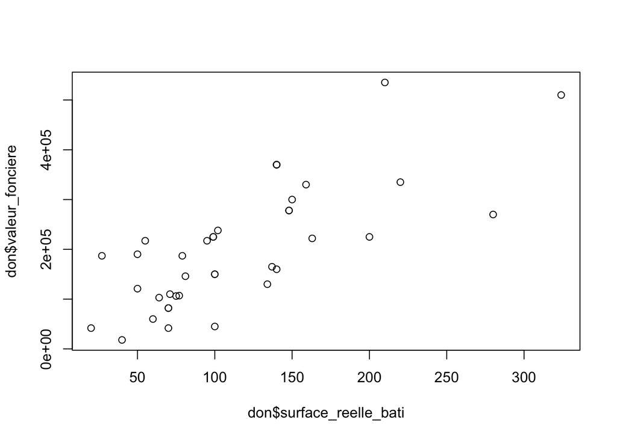

```r
plot(don$surface_reelle_bati,don$valeur_fonciere)
```